# Fourth R Markdown

Gian Nicole Villamayor, Jessica Dela Cruz, John Lester Santos, John Rollic Conducto

8/6/2021

## Received signal strength and local terrain profile data for radio network planning and optimization at GSM frequency bands

### **Introduction**

In the contemporary world, numerous advancements in technology are being discovered and utilized, in line with the goal of enhancing it further. Everything is constantly developing in such ways just like how instant messaging applications have taken over the mailman’s job.

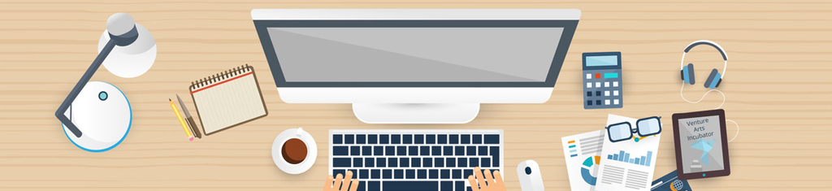

[— Image source —](https://2ee0tsdb27ngz4ba31r09l6e-wpengine.netdna-ssl.com/wp-content/uploads/2015/06/VAI-Twitter-Header-Flat.jpg)

During the 21st century, Smartphones and Smart TVs have shaped the world. Due to the large demand for these innovations, mobile networks have also been studied and improved in order to cope up with the development of smart devices. The Received Signal Strength (RSS) of the transmitted signals are investigated as well as the factors that affect the strength of radio waves in wireless channels. Terrain elevation, clutter height, altitude, and the distance from the mobile station are some of the variables that are significant in this research.

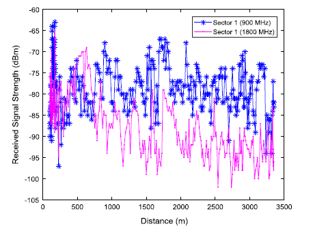

In radio network planning and optimization, the profile of the propagation environments and the local terrain are crucial in determining the performance of the radio waves. It varies depending on the terrain parameters and RSS of the location.

### **Methodology**

Since the behaviour of radio wave signals in a wireless channel depends on the local terrain profile of the propagation environments, the researchers in this study recorded the Received Signal Strength (RSS) of transmitted signals at different points in space for radio network planning and optimization. In this setup, RSS data of a commercial base station operating at 900 and 1800 MHz were measured along three different routes of Lagos-Badagry Highway, Nigeria. In addition, local terrain profile data of the study area (terrain elevation, clutter height, altitude, and the distance of the mobile station from the base station) are extracted from Digital Terrain Map (DTM) to account for the unique environmental features.  
The steps that the researchers have done in order to conclude the experiment were as follows:

[interactive chart not shown]

They first did an extensive measurement campaign along Lagos-Badagry Expressway, Nigeria and then plotted 3 different routes for their signals to go through the experiment. They expanded the radio coverage area of a base transceiver station to operate at 900 and 1800 MHz. Lastly, they performed the data collection process through the use of the Transmission Evaluation and Monitoring System (TEMS) network performance investigation software and explicated the results though certain statistical treatments.

### **Results and Discussion**

### 900 MHz

```
##
## Call:
## lm(formula = rss ~ elevation + altitude + distance, data = dt1)
##
## Residuals:
##     Min      1Q  Median      3Q     Max
## -16.200  -4.905  -1.897   2.811  36.877
##
## Coefficients:
##               Estimate Std. Error t value Pr(>|t|)
## (Intercept) -74.402204  12.258038  -6.070 7.74e-09 ***
## elevation    -1.347962   0.569148  -2.368    0.019 *
## altitude      0.252856   0.838252   0.302    0.763
## distance     -0.001454   0.001963  -0.741    0.460
## ---
## Signif. codes:  0 '***' 0.001 '**' 0.01 '*' 0.05 '.' 0.1 ' ' 1
##
## Residual standard error: 8.656 on 175 degrees of freedom
## Multiple R-squared:  0.09314,    Adjusted R-squared:  0.07759
## F-statistic: 5.991 on 3 and 175 DF,  p-value: 0.0006562
```

$$Signal\:Strength = -74.402204-1.347962\:terrain\:elevation+0.252856\:altitude-0.001454\:distance$$

### **T-test on each regression coefficient (α=0.05).**

**Hypotheses:**

$\large H_0:B_0=0,\: H_1:B_0\neq0,\:B_0=intercept$  
$\large H_0:B_1=0,\: H_1:B_1\neq0,\:B_1=coefficient\:of\:terrain\:elevation$  
$\large H_0:B_2=0,\: H_1:B_2\neq0,\:B_2=coefficient\:of\:altitude$  
$\large H_0:B_3=0,\: H_1:B_3\neq0,\:B_3=coefficient\:of\:distance$

**Reject** $H_0:B=0$ **if: the P-value is less than 0.05.**

**Test statistic:**

### **References**

[1] D. Montgomery and G. Runger, Applied statistics and probability for engineers, 7th ed. Wiley, 2017, pp. 262–279.

[2] S. I. Popoola, A. A. Atayero, and N. Faruk, “Received signal strength and local terrain profile data for radio network planning and optimization at GSM frequency bands,” Data in Brief, 19-Dec-2017. [Online]. Available: https://www.sciencedirect.com/science/article/pii/S235234091730731X?fbclid=IwAR0TQ-t3vYfTk29GxgbIEMz1yOLUhOU4Ki4CdHfe3mT_VNB9gH19kMMSrn8. [Accessed: 02-Aug-2021].

[3] R. Cunningham, “First Fun with RMarkdown,” RPubs. [Online]. Available: https://rpubs.com/redrobincl/241336. [Accessed: 02-Aug-2021].

[4] “T.Test: Student’s t-test,” RDocumentation. [Online]. Available: https://www.rdocumentation.org/packages/stats/versions/3.6.2/topics/t.test?fbclid=IwAR3X-DEeIaCng1ExhSWLP1CDcgXD0HdZbfbrKdnvb2LiLp343cl9Jgk9sbE. [Accessed: 30-Jul-2021].

[5] Z.Sun, “How to Use Tabbed Sections in Rmarkdown,” RPubs. [Online]. Available: https://rpubs.com/sunzhe96/596831#:~:text=To%20implement%20the%20tabbed%20section,file%20to%20an%20html%20file. [Accessed: 29-Jul-2021].